# Introduction of Data Science Life Cycle

The typical lifecycle of a data science project involves jumping back and forth among various interdependent data science tasks using variety of data science programming tools. Data science process begins with asking an interesting business question that guides the overall workflow of the data science project.

## Key Components of Life Cycle

The following data science life cycle diagrams shows the basic elements when doing a data science project.

[figure not shown]

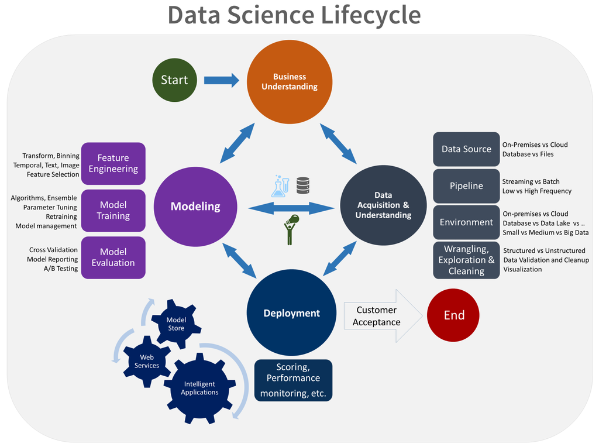

The following diagram shows how much percentage of work or the effort the data science team usually needs to put during the life cycle.

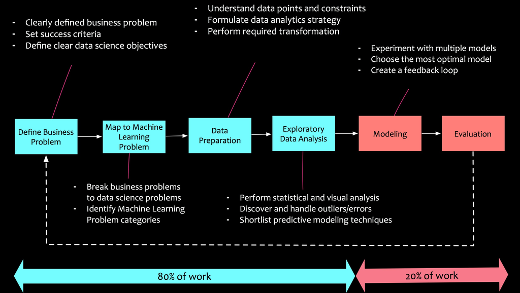

## Data Science Architecture

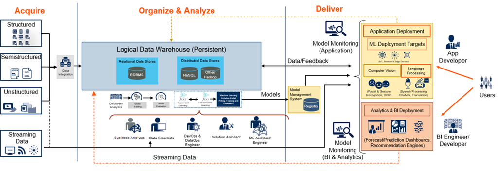

## Data Science Team Members

- **Product Sponsor or Owner**
  - Involve overseeing a range of data-related functions that may include data management, data quality and business data analytics strategy. He or she may also be responsible for data analytics and business intelligence, the process of drawing valuable insights from data.
  - Skill sets required: knowledge on data science and analytics, business domain expertise, leadership and visionary abilities.
- **Data Scientist and Data Analyst**
  - Solve complex problems and the curiosity to explore what problems are needed to be solved. A data scientist is an individual who develops machine learning models to make predictions and is well versed in algorithm development and computer science. This person will also know the complete life cycle of the model development.
  - Skill sets required: knowledge of big data platforms and tools like Seahorse powered by Apache Spark, JupyterLab, TensorFlow and MapReduce; and programming languages that include SQL, Python, Scala and Perl; and statistical computing languages, such as R. They should also have cloud computing capabilities and knowledge of various cloud platforms like AWS, Microsoft Azure etc.
- **Machine Learning Architect and/or Engineer**
  - Responsible for combining software engineering and machine modeling skills. This person determines which model to use and what data should be used for each model. Probability and statistics are also their forte.
  - Skill sets required: computer science and programming languages like R, Python, Scala, Java etc. They would also be required to have probability techniques, data modeling and evaluation techniques.
- **Data Architect and/or Engineer**
  - Able to conceptualize, visualize, and build an enterprise data management framework.
  - Skill sets required: programming languages frameworks like HTML5, RESTful services, Spark, Python, Hive, Kafka, and CSS etc. They should have the required knowledge and experience to handle database technologies such as PostgreSQL, MapReduce and MongoDB and visualization platforms such as; Tableau, PowerBI etc.
- **Business analyst**
  - Basically handles product owner’s role but on the operational level. This implies converting business expectations into data analysis. If your core data scientist lacks domain expertise, a business analyst can bridge the gap. They are responsible for using data analytics to assess processes, determine requirements and deliver data-driven recommendations and reports to executives and stakeholders.
  - Skill sets required: Excellent domain and industry expertise will be required. With this good communication as well as data visualization skills and knowledge of business intelligence tools will be good to have.
- **Data Visualization Engineer**
  - Involve having a solid understanding of UI development to create custom data visualization elements for your stakeholders. Regardless of the technology, successful data visualization engineers have to understand principles of design, both graphical and more generally user-centered design.
  - Skill sets required: A data visualization engineer need to have rigorous knowledge of data visualization methods and be able to produce various charts and graphs to represent data. Additionally they must understand the fundamentals of design principles and visual display of information.

# Business Problem Analysis - Principles

## Business objectives

Remember building a model is usually not the end goal of business. One interesting and important question is: what do you do next after we develop a perfect model? Knowing the objective is important because it will determine how you frame the problem, which algorithms you will select, which performance measure you will use to evaluate your model, and how much effort you will spend tweaking it.

## Current solution assessments

The next question to ask is what the current solution looks like (if any). The current situation or existing solutions will often give you a reference for performance, as well as insights on how to solve the problem.

## Key pain points

You also need to understand what the key pain points that the business is currently facing. This will help you to better understand why the business establish this data science project and focus on the main areas when designing and developing your solutions. This step also helps you to ensure your solutions can provide the best user experience and meet their expectations.

## Frame the problem

With all the information, you are now ready to start designing your system. First, you need to frame the problem: is it supervised, unsupervised, or Reinforcement Learning? Is it a classification task, a regression task, or something else? Should you use batch learning or on-line learning techniques?

## Setup evaluation metrics

Your next step is to select a performance measure. You should consider a **single-number evaluation metric**.

- Having a single-number evaluation metric such as accuracy allows you to sort all your models according to their performance on this metric, and quickly decide what is working best.
- Having a single-number evaluation metric speeds up your ability to make a decision when you are selecting among a large number of classifiers. It gives a clear preference ranking among all of them, and therefore a clear direction for progress.

# Data Science Experiments

Experiments are designed to identify causal relationships between variables and this is a really important concept in many fields and particularly relevant for data scientists today.

## Principles

- **Understand the Data Science Hierarchy of Needs** (see the diagram below).

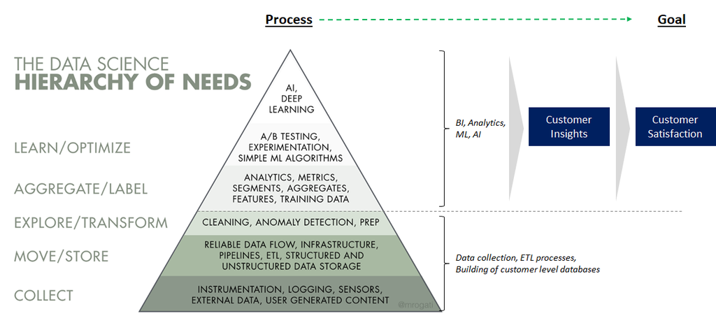

- **Pick projects that add the most value for the business**

Calculating the size of the opportunity before building a machine learning model can help determine a project’s potential impact on the business. This potential impact can then be weighed against the estimated time spent on the project to gauge project convexity.

Generic formula to calculate size of business opportunity:

`Estimated project impact = number of customers affected * target size of effect`

- **Iterate fast**

- **Data is no magic bullet**

Understanding the limitations of data and how machine learning algorithms work is important to know which models are worth building. The effectiveness of machine learning algorithms is only as good the data used, and many times, the data collected does not fully represent reality, especially when it comes to human behavior.

- **Models must be carefully evaluated by the business before moving to implementation stage**

Business stakeholders should carefully evaluate the output from machine learning models before deployment. **Apply business rules as a safe-guard**. Having an extra layer of business rules is imperative for quality assurance, as well as help prevent a faulty machine learning model that compromises customer experience from being launched. Deciding what business rules to implement stem from sanity checks conducted by the business.

## Best Practices

- **Use Jupyter Notebook template**

- **Structure your notebooks**
  - Give your notebook a title (H1 header) and a meaningful preamble to describe its purpose and contents.
  - Use headings and documentation in Markdown cells to structure your notebook and explain your workflow steps. Remember: You’re not only doing this for your colleagues or your successor, but also for your future self.
  - The toc2 extension can automatically create heading numbers and a Table of Contents, both in a sidebar (optionally a floating window) and in a markdown cell. The highlighting indicates your current position in the document — this will help you keep oriented in long notebooks.
  - Use template of notebooks to have a default structure and common imports.
- **Use `autoreload` IPython extension to help reloading modules before executing new code**

```python
%load_ext autoreload
%autoreload
```

- **Use classic notebooks extensions, including**
1. **code_prettify** backed by autopep8 is great for reformatting code in notebook code cells based on PEP 8 Style Guide
2. **spellchecker** highlights incorrectly spelled words
3. **Table of Contents (2)** enables to collect all running headers and display them in a floating window, as a sidebar or with a navigation menu
4. **AutoSaveTime** Optionally set the notebook autosave interval, and/or add a selector to the toolbar to set it
5. **ExecuteTime** Display when each cell has been executed and how long it took
6. **Autopep8** Use kernel-specific code to reformat/prettify the contents of code cells
- **Enable multiple displaying and automated formatting**

```python
from IPython.core.interactiveshell import InteractiveShell
InteractiveShell.ast_node_interactivity = "all"

from sklearn import datasets
iris = datasets.load_iris()
iris.data
iris.target
```

```
array([[5.1, 3.5, 1.4, 0.2],
       [4.9, 3. , 1.4, 0.2],
       [4.7, 3.2, 1.3, 0.2],
       [4.6, 3.1, 1.5, 0.2],
       [5. , 3.6, 1.4, 0.2],
       [5.4, 3.9, 1.7, 0.4],
       [4.6, 3.4, 1.4, 0.3],
       [5. , 3.4, 1.5, 0.2],
       [4.4, 2.9, 1.4, 0.2],
       [4.9, 3.1, 1.5, 0.1],
       [5.4, 3.7, 1.5, 0.2],
       [4.8, 3.4, 1.6, 0.2],
       [4.8, 3. , 1.4, 0.1],
       [4.3, 3. , 1.1, 0.1],
       [5.8, 4. , 1.2, 0.2],
       [5.7, 4.4, 1.5, 0.4],
       [5.4, 3.9, 1.3, 0.4],
       [5.1, 3.5, 1.4, 0.3],
       [5.7, 3.8, 1.7, 0.3],
       [5.1, 3.8, 1.5, 0.3],
       [5.4, 3.4, 1.7, 0.2],
       [5.1, 3.7, 1.5, 0.4],
       [4.6, 3.6, 1. , 0.2],
       [5.1, 3.3, 1.7, 0.5],
       [4.8, 3.4, 1.9, 0.2],
       [5. , 3. , 1.6, 0.2],
       [5. , 3.4, 1.6, 0.4],
       [5.2, 3.5, 1.5, 0.2],
       [5.2, 3.4, 1.4, 0.2],
       [4.7, 3.2, 1.6, 0.2],
       [4.8, 3.1, 1.6, 0.2],
       [5.4, 3.4, 1.5, 0.4],
       [5.2, 4.1, 1.5, 0.1],
       [5.5, 4.2, 1.4, 0.2],
       [4.9, 3.1, 1.5, 0.2],
       [5. , 3.2, 1.2, 0.2],
       [5.5, 3.5, 1.3, 0.2],
       [4.9, 3.6, 1.4, 0.1],
       [4.4, 3. , 1.3, 0.2],
       [5.1, 3.4, 1.5, 0.2],
```

[output cut: 95 more lines]

```
       [7.7, 3. , 6.1, 2.3],
       [6.3, 3.4, 5.6, 2.4],
       [6.4, 3.1, 5.5, 1.8],
       [6. , 3. , 4.8, 1.8],
       [6.9, 3.1, 5.4, 2.1],
       [6.7, 3.1, 5.6, 2.4],
       [6.9, 3.1, 5.1, 2.3],
       [5.8, 2.7, 5.1, 1.9],
       [6.8, 3.2, 5.9, 2.3],
       [6.7, 3.3, 5.7, 2.5],
       [6.7, 3. , 5.2, 2.3],
       [6.3, 2.5, 5. , 1.9],
       [6.5, 3. , 5.2, 2. ],
       [6.2, 3.4, 5.4, 2.3],
       [5.9, 3. , 5.1, 1.8]])
```

```
array([0, 0, 0, 0, 0, 0, 0, 0, 0, 0, 0, 0, 0, 0, 0, 0, 0, 0, 0, 0, 0, 0,
       0, 0, 0, 0, 0, 0, 0, 0, 0, 0, 0, 0, 0, 0, 0, 0, 0, 0, 0, 0, 0, 0,
       0, 0, 0, 0, 0, 0, 1, 1, 1, 1, 1, 1, 1, 1, 1, 1, 1, 1, 1, 1, 1, 1,
       1, 1, 1, 1, 1, 1, 1, 1, 1, 1, 1, 1, 1, 1, 1, 1, 1, 1, 1, 1, 1, 1,
       1, 1, 1, 1, 1, 1, 1, 1, 1, 1, 1, 1, 2, 2, 2, 2, 2, 2, 2, 2, 2, 2,
       2, 2, 2, 2, 2, 2, 2, 2, 2, 2, 2, 2, 2, 2, 2, 2, 2, 2, 2, 2, 2, 2,
       2, 2, 2, 2, 2, 2, 2, 2, 2, 2, 2, 2, 2, 2, 2, 2, 2, 2])
```

# Data Science Modeling

## Principles

- **Build models that answer the right questions**.

Communicating with ends users, understanding business rules that are already in place, looking at existing data and thinking of how to define the “ground truth” for the model to be trained on such that it is meaningful for end users, understanding the limitations of the proposed model, and stress testing the predicted output of the model with business users.

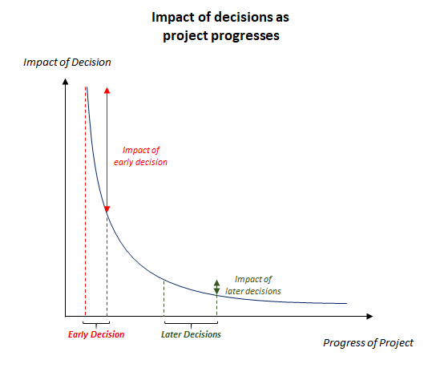

## Best Practices

- **Use machine learning model selection guidances or cheat sheets**

The following diagram shows some tips for selecting proper machine learning algorithms.

[figure not shown]

- **Be as conservative as you can when choosing modeling technology**

You would like to use the latest framework that has half a star on a Github repository that’s been published 3 years ago and never touched ever since (sorry, no links). Don’t do that, please!!!

You’re going to have a lot of uncertainty to deal with, so please avoid skating on thin ice.